# Risk Factor Analysis

## Outcome Variable

**Outcome Variable:** stunted

## Predictor Variables

**Intervention Variable:** parity

**Adjustment Set:**

unadjusted

## Stratifying Variables

The analysis was stratified on these variable(s):

- agecat
- studyid

The following strata were considered:

- agecat: 12 months, studyid: ki1000304b-SAS-FoodSuppl
- agecat: 12 months, studyid: ki1017093b-PROVIDE
- agecat: 12 months, studyid: ki1066203-TanzaniaChild2
- agecat: 12 months, studyid: ki1101329-Keneba
- agecat: 12 months, studyid: ki1113344-GMS-Nepal
- agecat: 12 months, studyid: ki1126311-ZVITAMBO
- agecat: 12 months, studyid: ki1135781-COHORTS
- agecat: 18 months, studyid: ki1000304b-SAS-FoodSuppl
- agecat: 18 months, studyid: ki1017093b-PROVIDE
- agecat: 18 months, studyid: ki1066203-TanzaniaChild2
- agecat: 18 months, studyid: ki1101329-Keneba
- agecat: 18 months, studyid: ki1113344-GMS-Nepal
- agecat: 18 months, studyid: ki1126311-ZVITAMBO
- agecat: 18 months, studyid: ki1135781-COHORTS
- agecat: 24 months, studyid: ki1017093b-PROVIDE
- agecat: 24 months, studyid: ki1066203-TanzaniaChild2
- agecat: 24 months, studyid: ki1101329-Keneba
- agecat: 24 months, studyid: ki1113344-GMS-Nepal
- agecat: 24 months, studyid: ki1126311-ZVITAMBO
- agecat: 24 months, studyid: ki1135781-COHORTS
- agecat: 3 months, studyid: ki1000304b-SAS-FoodSuppl
- agecat: 3 months, studyid: ki1017093b-PROVIDE
- agecat: 3 months, studyid: ki1066203-TanzaniaChild2
- agecat: 3 months, studyid: ki1101329-Keneba
- agecat: 3 months, studyid: ki1113344-GMS-Nepal
- agecat: 3 months, studyid: ki1126311-ZVITAMBO
- agecat: 3 months, studyid: ki1135781-COHORTS
- agecat: 6 months, studyid: ki1000304b-SAS-FoodSuppl
- agecat: 6 months, studyid: ki1017093b-PROVIDE
- agecat: 6 months, studyid: ki1066203-TanzaniaChild2
- agecat: 6 months, studyid: ki1101329-Keneba
- agecat: 6 months, studyid: ki1113344-GMS-Nepal
- agecat: 6 months, studyid: ki1126311-ZVITAMBO
- agecat: 6 months, studyid: ki1135781-COHORTS
- agecat: 9 months, studyid: ki1000304b-SAS-FoodSuppl
- agecat: 9 months, studyid: ki1017093b-PROVIDE
- agecat: 9 months, studyid: ki1066203-TanzaniaChild2
- agecat: 9 months, studyid: ki1101329-Keneba
- agecat: 9 months, studyid: ki1113344-GMS-Nepal
- agecat: 9 months, studyid: ki1126311-ZVITAMBO
- agecat: 9 months, studyid: ki1135781-COHORTS
- agecat: Birth, studyid: ki1101329-Keneba
- agecat: Birth, studyid: ki1126311-ZVITAMBO
- agecat: Birth, studyid: ki1135781-COHORTS

### Dropped Strata

Some strata were dropped due to rare outcomes:

- agecat: 12 months, studyid: ki1000304b-SAS-FoodSuppl
- agecat: 18 months, studyid: ki1000304b-SAS-FoodSuppl
- agecat: 24 months, studyid: ki1066203-TanzaniaChild2
- agecat: 3 months, studyid: ki1017093b-PROVIDE
- agecat: 6 months, studyid: ki1017093b-PROVIDE

## Methods Detail

We’re interested in the causal parameters $E[Y_a]$ for all values of $a \in \mathcal{A}$. These parameters represent the mean outcome if, possibly contrary to fact, we intervened to set all units to have $A=a$. Under the randomization and positivity assumptions, these are identified by the statistical parameters $\psi_a=E_W[E_{Y|A,W}(Y|A=a,W)]$. In addition, we’re interested in the mean of $Y$, $E[Y]$ under no intervention (the observed mean). We will estimate these parameters by using SuperLearner to fit the relevant likelihood factors – $E_{Y|A,W}(Y|A=a,W)$ and $p(A=a|W)$, and then updating our likelihood fit using a joint TMLE.

For unadjusted analyses ($W=\{\}$), initial likelihoods were estimated using Lrnr_glm to estimate the simple $E(Y|A)$ and Lrnr_mean to estimate $p(A)$. For adjusted analyses, a small library containing Lrnr_glmnet, Lrnr_xgboost, and Lrnr_mean was used.

Having estimated these parameters, we will then use the delta method to estimate relative risks and attributable risks relative to a prespecified baseline level of $A$.

# Results Detail

## Results Plots

[figure not shown]

[figure not shown]

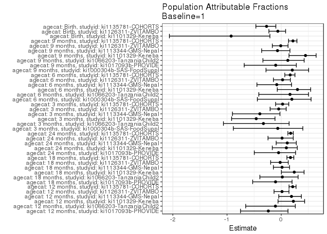

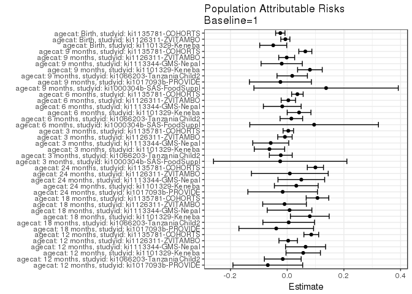

## Data Summary

| agecat | studyid | A | n | nA | nAY0 | nAY1 |
| --- | --- | --- | --- | --- | --- | --- |
| 12 months | ki1000304b-SAS-FoodSuppl | 1 | 91 | 17 | 5 | 12 |
| 12 months | ki1000304b-SAS-FoodSuppl | 2 | 91 | 18 | 3 | 15 |
| 12 months | ki1000304b-SAS-FoodSuppl | 3+ | 91 | 56 | 11 | 45 |
| 12 months | ki1017093b-PROVIDE | 1 | 153 | 59 | 38 | 21 |
| 12 months | ki1017093b-PROVIDE | 2 | 153 | 56 | 40 | 16 |
| 12 months | ki1017093b-PROVIDE | 3+ | 153 | 38 | 31 | 7 |
| 12 months | ki1066203-TanzaniaChild2 | 1 | 350 | 124 | 104 | 20 |
| 12 months | ki1066203-TanzaniaChild2 | 2 | 350 | 119 | 107 | 12 |
| 12 months | ki1066203-TanzaniaChild2 | 3+ | 350 | 107 | 88 | 19 |
| 12 months | ki1101329-Keneba | 1 | 1530 | 164 | 132 | 32 |
| 12 months | ki1101329-Keneba | 2 | 1530 | 154 | 133 | 21 |
| 12 months | ki1101329-Keneba | 3+ | 1530 | 1212 | 880 | 332 |
| 12 months | ki1113344-GMS-Nepal | 1 | 558 | 155 | 112 | 43 |
| 12 months | ki1113344-GMS-Nepal | 2 | 558 | 140 | 95 | 45 |
| 12 months | ki1113344-GMS-Nepal | 3+ | 558 | 263 | 160 | 103 |
| 12 months | ki1126311-ZVITAMBO | 1 | 1701 | 648 | 496 | 152 |
| 12 months | ki1126311-ZVITAMBO | 2 | 1701 | 515 | 399 | 116 |
| 12 months | ki1126311-ZVITAMBO | 3+ | 1701 | 538 | 401 | 137 |
| 12 months | ki1135781-COHORTS | 1 | 6533 | 1227 | 839 | 388 |
| 12 months | ki1135781-COHORTS | 2 | 6533 | 1491 | 997 | 494 |
| 12 months | ki1135781-COHORTS | 3+ | 6533 | 3815 | 2076 | 1739 |
| 18 months | ki1000304b-SAS-FoodSuppl | 1 | 82 | 15 | 2 | 13 |
| 18 months | ki1000304b-SAS-FoodSuppl | 2 | 82 | 17 | 1 | 16 |
| 18 months | ki1000304b-SAS-FoodSuppl | 3+ | 82 | 50 | 7 | 43 |
| 18 months | ki1017093b-PROVIDE | 1 | 141 | 54 | 32 | 22 |
| 18 months | ki1017093b-PROVIDE | 2 | 141 | 51 | 32 | 19 |
| 18 months | ki1017093b-PROVIDE | 3+ | 141 | 36 | 25 | 11 |
| 18 months | ki1066203-TanzaniaChild2 | 1 | 254 | 89 | 66 | 23 |
| 18 months | ki1066203-TanzaniaChild2 | 2 | 254 | 91 | 67 | 24 |
| 18 months | ki1066203-TanzaniaChild2 | 3+ | 254 | 74 | 54 | 20 |

[output cut: 117 more lines]

## Results Table

### Parameter: TSM

| agecat | studyid | intervention_level | baseline_level | estimate | ci_lower | ci_upper |
| --- | --- | --- | --- | --- | --- | --- |
| 12 months | ki1017093b-PROVIDE | 1 | NA | 0.3559322 | 0.2333590 | 0.4785054 |
| 12 months | ki1017093b-PROVIDE | 2 | NA | 0.2857143 | 0.1670063 | 0.4044223 |
| 12 months | ki1017093b-PROVIDE | 3+ | NA | 0.1842105 | 0.0605513 | 0.3078697 |
| 12 months | ki1066203-TanzaniaChild2 | 1 | NA | 0.1612903 | 0.0964614 | 0.2261192 |
| 12 months | ki1066203-TanzaniaChild2 | 2 | NA | 0.1008403 | 0.0466613 | 0.1550194 |
| 12 months | ki1066203-TanzaniaChild2 | 3+ | NA | 0.1775701 | 0.1050578 | 0.2500824 |
| 12 months | ki1101329-Keneba | 1 | NA | 0.1951220 | 0.1344502 | 0.2557937 |
| 12 months | ki1101329-Keneba | 2 | NA | 0.1363636 | 0.0821455 | 0.1905818 |
| 12 months | ki1101329-Keneba | 3+ | NA | 0.2739274 | 0.2488116 | 0.2990432 |
| 12 months | ki1113344-GMS-Nepal | 1 | NA | 0.2774194 | 0.2068716 | 0.3479671 |
| 12 months | ki1113344-GMS-Nepal | 2 | NA | 0.3214286 | 0.2439978 | 0.3988593 |
| 12 months | ki1113344-GMS-Nepal | 3+ | NA | 0.3916350 | 0.3325901 | 0.4506799 |
| 12 months | ki1126311-ZVITAMBO | 1 | NA | 0.2345679 | 0.2019335 | 0.2672023 |
| 12 months | ki1126311-ZVITAMBO | 2 | NA | 0.2252427 | 0.1891533 | 0.2613322 |
| 12 months | ki1126311-ZVITAMBO | 3+ | NA | 0.2546468 | 0.2178225 | 0.2914712 |
| 12 months | ki1135781-COHORTS | 1 | NA | 0.3162184 | 0.2901982 | 0.3422387 |
| 12 months | ki1135781-COHORTS | 2 | NA | 0.3313213 | 0.3074280 | 0.3552145 |
| 12 months | ki1135781-COHORTS | 3+ | NA | 0.4558322 | 0.4400269 | 0.4716375 |
| 18 months | ki1017093b-PROVIDE | 1 | NA | 0.4074074 | 0.2758882 | 0.5389267 |
| 18 months | ki1017093b-PROVIDE | 2 | NA | 0.3725490 | 0.2393840 | 0.5057140 |
| 18 months | ki1017093b-PROVIDE | 3+ | NA | 0.3055556 | 0.1545454 | 0.4565657 |
| 18 months | ki1066203-TanzaniaChild2 | 1 | NA | 0.2584270 | 0.1672982 | 0.3495557 |
| 18 months | ki1066203-TanzaniaChild2 | 2 | NA | 0.2637363 | 0.1730199 | 0.3544526 |
| 18 months | ki1066203-TanzaniaChild2 | 3+ | NA | 0.2702703 | 0.1688864 | 0.3716542 |
| 18 months | ki1101329-Keneba | 1 | NA | 0.2516129 | 0.1832764 | 0.3199494 |
| 18 months | ki1101329-Keneba | 2 | NA | 0.2039474 | 0.1398711 | 0.2680236 |
| 18 months | ki1101329-Keneba | 3+ | NA | 0.3570850 | 0.3303538 | 0.3838162 |
| 18 months | ki1113344-GMS-Nepal | 1 | NA | 0.5225806 | 0.4438753 | 0.6012860 |
| 18 months | ki1113344-GMS-Nepal | 2 | NA | 0.5035461 | 0.4209437 | 0.5861485 |
| 18 months | ki1113344-GMS-Nepal | 3+ | NA | 0.5511811 | 0.4899589 | 0.6124033 |

[output cut: 87 more lines]

### Parameter: E(Y)

| agecat | studyid | intervention_level | baseline_level | estimate | ci_lower | ci_upper |
| --- | --- | --- | --- | --- | --- | --- |
| 12 months | ki1017093b-PROVIDE | NA | NA | 0.2875817 | 0.2769688 | 0.2981946 |
| 12 months | ki1066203-TanzaniaChild2 | NA | NA | 0.1457143 | 0.1422651 | 0.1491635 |
| 12 months | ki1101329-Keneba | NA | NA | 0.2516340 | 0.2493516 | 0.2539164 |
| 12 months | ki1113344-GMS-Nepal | NA | NA | 0.3422939 | 0.3382037 | 0.3463841 |
| 12 months | ki1126311-ZVITAMBO | NA | NA | 0.2380952 | 0.2375300 | 0.2386605 |
| 12 months | ki1135781-COHORTS | NA | NA | 0.4011939 | 0.3996197 | 0.4027681 |
| 18 months | ki1017093b-PROVIDE | NA | NA | 0.3687943 | 0.3621743 | 0.3754143 |
| 18 months | ki1066203-TanzaniaChild2 | NA | NA | 0.2637795 | 0.2631975 | 0.2643616 |
| 18 months | ki1101329-Keneba | NA | NA | 0.3313878 | 0.3287603 | 0.3340153 |
| 18 months | ki1113344-GMS-Nepal | NA | NA | 0.5309091 | 0.5292334 | 0.5325848 |
| 18 months | ki1126311-ZVITAMBO | NA | NA | 0.4752941 | 0.4699031 | 0.4806851 |
| 18 months | ki1135781-COHORTS | NA | NA | 0.6250000 | 0.6225439 | 0.6274561 |
| 24 months | ki1017093b-PROVIDE | NA | NA | 0.3288591 | 0.3267226 | 0.3309955 |
| 24 months | ki1101329-Keneba | NA | NA | 0.3386628 | 0.3369549 | 0.3403706 |
| 24 months | ki1113344-GMS-Nepal | NA | NA | 0.4468938 | 0.4441404 | 0.4496472 |
| 24 months | ki1126311-ZVITAMBO | NA | NA | 0.5862069 | 0.5741544 | 0.5982594 |
| 24 months | ki1135781-COHORTS | NA | NA | 0.5724866 | 0.5707515 | 0.5742217 |
| 3 months | ki1000304b-SAS-FoodSuppl | NA | NA | 0.3870968 | 0.3843304 | 0.3898631 |
| 3 months | ki1066203-TanzaniaChild2 | NA | NA | 0.0687831 | 0.0672383 | 0.0703279 |
| 3 months | ki1101329-Keneba | NA | NA | 0.1355832 | 0.1344490 | 0.1367174 |
| 3 months | ki1113344-GMS-Nepal | NA | NA | 0.1471103 | 0.1441857 | 0.1500349 |
| 3 months | ki1126311-ZVITAMBO | NA | NA | 0.1721708 | 0.1715649 | 0.1727768 |
| 3 months | ki1135781-COHORTS | NA | NA | 0.1527004 | 0.1522520 | 0.1531488 |
| 6 months | ki1000304b-SAS-FoodSuppl | NA | NA | 0.4838710 | 0.4684465 | 0.4992954 |
| 6 months | ki1066203-TanzaniaChild2 | NA | NA | 0.0907258 | 0.0896563 | 0.0917953 |
| 6 months | ki1101329-Keneba | NA | NA | 0.1398645 | 0.1386216 | 0.1411073 |
| 6 months | ki1113344-GMS-Nepal | NA | NA | 0.2113677 | 0.2103334 | 0.2124020 |
| 6 months | ki1126311-ZVITAMBO | NA | NA | 0.1632554 | 0.1626961 | 0.1638146 |
| 6 months | ki1135781-COHORTS | NA | NA | 0.2174729 | 0.2166725 | 0.2182732 |
| 9 months | ki1000304b-SAS-FoodSuppl | NA | NA | 0.6705882 | 0.6522713 | 0.6889052 |
| 9 months | ki1017093b-PROVIDE | NA | NA | 0.2341772 | 0.2306065 | 0.2377479 |
| 9 months | ki1066203-TanzaniaChild2 | NA | NA | 0.1451991 | 0.1439284 | 0.1464697 |
| 9 months | ki1101329-Keneba | NA | NA | 0.1790769 | 0.1765691 | 0.1815848 |
| 9 months | ki1113344-GMS-Nepal | NA | NA | 0.2813067 | 0.2800212 | 0.2825922 |
| 9 months | ki1126311-ZVITAMBO | NA | NA | 0.1946001 | 0.1942614 | 0.1949388 |
| 9 months | ki1135781-COHORTS | NA | NA | 0.2956446 | 0.2944867 | 0.2968026 |
| Birth | ki1101329-Keneba | NA | NA | 0.0533049 | 0.0523854 | 0.0542244 |
| Birth | ki1126311-ZVITAMBO | NA | NA | 0.1043781 | 0.1041904 | 0.1045658 |
| Birth | ki1135781-COHORTS | NA | NA | 0.0898535 | 0.0895851 | 0.0901220 |

### Parameter: RR

| agecat | studyid | intervention_level | baseline_level | estimate | ci_lower | ci_upper |
| --- | --- | --- | --- | --- | --- | --- |
| 12 months | ki1017093b-PROVIDE | 2 | 1 | 0.8027211 | 0.4679515 | 1.3769828 |
| 12 months | ki1017093b-PROVIDE | 3+ | 1 | 0.5175439 | 0.2433798 | 1.1005499 |
| 12 months | ki1066203-TanzaniaChild2 | 2 | 1 | 0.6252101 | 0.3196106 | 1.2230123 |
| 12 months | ki1066203-TanzaniaChild2 | 3+ | 1 | 1.1009346 | 0.6207507 | 1.9525664 |
| 12 months | ki1101329-Keneba | 2 | 1 | 0.6988636 | 0.4218744 | 1.1577153 |
| 12 months | ki1101329-Keneba | 3+ | 1 | 1.4038779 | 1.0151735 | 1.9414150 |
| 12 months | ki1113344-GMS-Nepal | 2 | 1 | 1.1586379 | 0.8162460 | 1.6446534 |
| 12 months | ki1113344-GMS-Nepal | 3+ | 1 | 1.4117075 | 1.0503960 | 1.8973016 |
| 12 months | ki1126311-ZVITAMBO | 2 | 1 | 0.9602453 | 0.7766508 | 1.1872400 |
| 12 months | ki1126311-ZVITAMBO | 3+ | 1 | 1.0855997 | 0.8882199 | 1.3268411 |
| 12 months | ki1135781-COHORTS | 2 | 1 | 1.0477608 | 0.9391696 | 1.1689078 |
| 12 months | ki1135781-COHORTS | 3+ | 1 | 1.4415107 | 1.3183738 | 1.5761487 |
| 18 months | ki1017093b-PROVIDE | 2 | 1 | 0.9144385 | 0.5649115 | 1.4802279 |
| 18 months | ki1017093b-PROVIDE | 3+ | 1 | 0.7500000 | 0.4156182 | 1.3534056 |
| 18 months | ki1066203-TanzaniaChild2 | 2 | 1 | 1.0205447 | 0.6235860 | 1.6701970 |
| 18 months | ki1066203-TanzaniaChild2 | 3+ | 1 | 1.0458284 | 0.6249818 | 1.7500624 |
| 18 months | ki1101329-Keneba | 2 | 1 | 0.8105601 | 0.5350860 | 1.2278543 |
| 18 months | ki1101329-Keneba | 3+ | 1 | 1.4191841 | 1.0707512 | 1.8810004 |
| 18 months | ki1113344-GMS-Nepal | 2 | 1 | 0.9635759 | 0.7712073 | 1.2039286 |
| 18 months | ki1113344-GMS-Nepal | 3+ | 1 | 1.0547293 | 0.8747179 | 1.2717859 |
| 18 months | ki1126311-ZVITAMBO | 2 | 1 | 0.8081224 | 0.6145757 | 1.0626221 |
| 18 months | ki1126311-ZVITAMBO | 3+ | 1 | 1.1042967 | 0.8856833 | 1.3768704 |
| 18 months | ki1135781-COHORTS | 2 | 1 | 1.1145146 | 1.0060487 | 1.2346747 |
| 18 months | ki1135781-COHORTS | 3+ | 1 | 1.3122212 | 1.2072224 | 1.4263522 |
| 24 months | ki1017093b-PROVIDE | 2 | 1 | 0.9129630 | 0.5365312 | 1.5535004 |
| 24 months | ki1017093b-PROVIDE | 3+ | 1 | 0.9405405 | 0.5229863 | 1.6914717 |
| 24 months | ki1101329-Keneba | 2 | 1 | 0.8213429 | 0.5607645 | 1.2030081 |
| 24 months | ki1101329-Keneba | 3+ | 1 | 1.1535281 | 0.8856088 | 1.5024999 |
| 24 months | ki1113344-GMS-Nepal | 2 | 1 | 1.2011396 | 0.9126383 | 1.5808414 |
| 24 months | ki1113344-GMS-Nepal | 3+ | 1 | 1.1565729 | 0.9008628 | 1.4848662 |
| 24 months | ki1126311-ZVITAMBO | 2 | 1 | 0.8666667 | 0.5644922 | 1.3305961 |
| 24 months | ki1126311-ZVITAMBO | 3+ | 1 | 1.1725490 | 0.8426527 | 1.6315989 |
| 24 months | ki1135781-COHORTS | 2 | 1 | 1.0657609 | 0.9851635 | 1.1529521 |
| 24 months | ki1135781-COHORTS | 3+ | 1 | 1.3356098 | 1.2515769 | 1.4252848 |
| 3 months | ki1000304b-SAS-FoodSuppl | 2 | 1 | 0.8947368 | 0.3930436 | 2.0368071 |
| 3 months | ki1000304b-SAS-FoodSuppl | 3+ | 1 | 0.9373434 | 0.4847964 | 1.8123330 |
| 3 months | ki1066203-TanzaniaChild2 | 2 | 1 | 0.7371906 | 0.3713092 | 1.4636047 |
| 3 months | ki1066203-TanzaniaChild2 | 3+ | 1 | 0.4946642 | 0.2204028 | 1.1102064 |
| 3 months | ki1101329-Keneba | 2 | 1 | 0.6101518 | 0.3789033 | 0.9825335 |
| 3 months | ki1101329-Keneba | 3+ | 1 | 0.6431329 | 0.4735342 | 0.8734743 |
| 3 months | ki1113344-GMS-Nepal | 2 | 1 | 0.6258446 | 0.3714623 | 1.0544313 |
| 3 months | ki1113344-GMS-Nepal | 3+ | 1 | 0.6025281 | 0.3862177 | 0.9399883 |
| 3 months | ki1126311-ZVITAMBO | 2 | 1 | 0.8313723 | 0.6618871 | 1.0442566 |
| 3 months | ki1126311-ZVITAMBO | 3+ | 1 | 1.0198218 | 0.8270683 | 1.2574976 |
| 3 months | ki1135781-COHORTS | 2 | 1 | 0.8004632 | 0.6714654 | 0.9542433 |
| 3 months | ki1135781-COHORTS | 3+ | 1 | 1.1280750 | 0.9803493 | 1.2980609 |
| 6 months | ki1000304b-SAS-FoodSuppl | 2 | 1 | 1.0000000 | 0.4389277 | 2.2782796 |
| 6 months | ki1000304b-SAS-FoodSuppl | 3+ | 1 | 1.3984962 | 0.7452718 | 2.6242663 |
| 6 months | ki1066203-TanzaniaChild2 | 2 | 1 | 1.3846154 | 0.7001733 | 2.7381219 |
| 6 months | ki1066203-TanzaniaChild2 | 3+ | 1 | 1.1958042 | 0.5799944 | 2.4654510 |
| 6 months | ki1101329-Keneba | 2 | 1 | 0.8716305 | 0.4511824 | 1.6838859 |
| 6 months | ki1101329-Keneba | 3+ | 1 | 1.5658831 | 1.0020575 | 2.4469551 |
| 6 months | ki1113344-GMS-Nepal | 2 | 1 | 0.8508150 | 0.5491611 | 1.3181671 |
| 6 months | ki1113344-GMS-Nepal | 3+ | 1 | 0.9211823 | 0.6336271 | 1.3392368 |
| 6 months | ki1126311-ZVITAMBO | 2 | 1 | 0.9378305 | 0.7314442 | 1.2024514 |
| 6 months | ki1126311-ZVITAMBO | 3+ | 1 | 1.1389383 | 0.9064798 | 1.4310086 |
| 6 months | ki1135781-COHORTS | 2 | 1 | 0.9508475 | 0.8173606 | 1.1061348 |
| 6 months | ki1135781-COHORTS | 3+ | 1 | 1.3643589 | 1.2058957 | 1.5436453 |
| 9 months | ki1000304b-SAS-FoodSuppl | 2 | 1 | 1.1029412 | 0.5921691 | 2.0542766 |
| 9 months | ki1000304b-SAS-FoodSuppl | 3+ | 1 | 1.3797170 | 0.8342741 | 2.2817668 |
| 9 months | ki1017093b-PROVIDE | 2 | 1 | 0.8995536 | 0.4750662 | 1.7033345 |
| 9 months | ki1017093b-PROVIDE | 3+ | 1 | 0.7750000 | 0.3652663 | 1.6443481 |
| 9 months | ki1066203-TanzaniaChild2 | 2 | 1 | 1.1816871 | 0.6679443 | 2.0905702 |
| 9 months | ki1066203-TanzaniaChild2 | 3+ | 1 | 1.2476077 | 0.7018059 | 2.2178851 |
| 9 months | ki1101329-Keneba | 2 | 1 | 0.6203136 | 0.2948401 | 1.3050767 |
| 9 months | ki1101329-Keneba | 3+ | 1 | 2.0775174 | 1.3224257 | 3.2637586 |
| 9 months | ki1113344-GMS-Nepal | 2 | 1 | 0.8605959 | 0.5954841 | 1.2437366 |
| 9 months | ki1113344-GMS-Nepal | 3+ | 1 | 0.9391304 | 0.6879522 | 1.2820164 |
| 9 months | ki1126311-ZVITAMBO | 2 | 1 | 0.9353967 | 0.7487996 | 1.1684927 |
| 9 months | ki1126311-ZVITAMBO | 3+ | 1 | 1.0336699 | 0.8353840 | 1.2790208 |
| 9 months | ki1135781-COHORTS | 2 | 1 | 1.0483333 | 0.9192009 | 1.1956068 |
| 9 months | ki1135781-COHORTS | 3+ | 1 | 1.4560313 | 1.3066753 | 1.6224590 |
| Birth | ki1101329-Keneba | 2 | 1 | 0.5342466 | 0.2356709 | 1.2110933 |
| Birth | ki1101329-Keneba | 3+ | 1 | 0.4500000 | 0.2632335 | 0.7692791 |
| Birth | ki1126311-ZVITAMBO | 2 | 1 | 0.9027343 | 0.7137179 | 1.1418086 |
| Birth | ki1126311-ZVITAMBO | 3+ | 1 | 0.8925432 | 0.7029423 | 1.1332840 |
| Birth | ki1135781-COHORTS | 2 | 1 | 0.7032029 | 0.5682315 | 0.8702339 |
| Birth | ki1135781-COHORTS | 3+ | 1 | 0.7520118 | 0.6319227 | 0.8949223 |

### Parameter: PAR

| agecat | studyid | intervention_level | baseline_level | estimate | ci_lower | ci_upper |
| --- | --- | --- | --- | --- | --- | --- |
| 12 months | ki1017093b-PROVIDE | 1 | NA | -0.0683505 | -0.1913823 | 0.0546813 |
| 12 months | ki1066203-TanzaniaChild2 | 1 | NA | -0.0155760 | -0.0804966 | 0.0493445 |
| 12 months | ki1101329-Keneba | 1 | NA | 0.0565120 | -0.0042026 | 0.1172267 |
| 12 months | ki1113344-GMS-Nepal | 1 | NA | 0.0648746 | -0.0057917 | 0.1355408 |
| 12 months | ki1126311-ZVITAMBO | 1 | NA | 0.0035273 | -0.0291120 | 0.0361667 |
| 12 months | ki1135781-COHORTS | 1 | NA | 0.0849755 | 0.0589077 | 0.1110433 |
| 18 months | ki1017093b-PROVIDE | 1 | NA | -0.0386131 | -0.1702988 | 0.0930727 |
| 18 months | ki1066203-TanzaniaChild2 | 1 | NA | 0.0053526 | -0.0857781 | 0.0964832 |
| 18 months | ki1101329-Keneba | 1 | NA | 0.0797749 | 0.0113879 | 0.1481619 |
| 18 months | ki1113344-GMS-Nepal | 1 | NA | 0.0083284 | -0.0703947 | 0.0870516 |
| 18 months | ki1126311-ZVITAMBO | 1 | NA | -0.0093685 | -0.0863698 | 0.0676329 |
| 18 months | ki1135781-COHORTS | 1 | NA | 0.1068482 | 0.0669828 | 0.1467135 |
| 24 months | ki1017093b-PROVIDE | 1 | NA | -0.0159685 | -0.1387240 | 0.1067870 |
| 24 months | ki1101329-Keneba | 1 | NA | 0.0320934 | -0.0451600 | 0.1093469 |
| 24 months | ki1113344-GMS-Nepal | 1 | NA | 0.0498350 | -0.0325261 | 0.1321960 |
| 24 months | ki1126311-ZVITAMBO | 1 | NA | 0.0092838 | -0.1261174 | 0.1446850 |
| 24 months | ki1135781-COHORTS | 1 | NA | 0.0995136 | 0.0710200 | 0.1280073 |
| 3 months | ki1000304b-SAS-FoodSuppl | 1 | NA | -0.0246679 | -0.2599026 | 0.2105667 |
| 3 months | ki1066203-TanzaniaChild2 | 1 | NA | -0.0225875 | -0.0628883 | 0.0177134 |
| 3 months | ki1101329-Keneba | 1 | NA | -0.0625300 | -0.1162108 | -0.0088492 |
| 3 months | ki1113344-GMS-Nepal | 1 | NA | -0.0580179 | -0.1215055 | 0.0054697 |
| 3 months | ki1126311-ZVITAMBO | 1 | NA | -0.0079888 | -0.0334372 | 0.0174596 |
| 3 months | ki1135781-COHORTS | 1 | NA | 0.0039285 | -0.0145548 | 0.0224118 |
| 6 months | ki1000304b-SAS-FoodSuppl | 1 | NA | 0.0949821 | -0.1319718 | 0.3219359 |
| 6 months | ki1066203-TanzaniaChild2 | 1 | NA | 0.0147024 | -0.0250762 | 0.0544810 |
| 6 months | ki1101329-Keneba | 1 | NA | 0.0419263 | 0.0000694 | 0.0837832 |
| 6 months | ki1113344-GMS-Nepal | 1 | NA | -0.0173905 | -0.0840135 | 0.0492325 |
| 6 months | ki1126311-ZVITAMBO | 1 | NA | 0.0041075 | -0.0212857 | 0.0295007 |
| 6 months | ki1135781-COHORTS | 1 | NA | 0.0359834 | 0.0156532 | 0.0563135 |
| 9 months | ki1000304b-SAS-FoodSuppl | 1 | NA | 0.1372549 | -0.1173705 | 0.3918803 |
| 9 months | ki1017093b-PROVIDE | 1 | NA | -0.0238873 | -0.1332099 | 0.0854353 |
| 9 months | ki1066203-TanzaniaChild2 | 1 | NA | 0.0176823 | -0.0359527 | 0.0713173 |
| 9 months | ki1101329-Keneba | 1 | NA | 0.0801758 | 0.0367191 | 0.1236326 |
| 9 months | ki1113344-GMS-Nepal | 1 | NA | -0.0193469 | -0.0920820 | 0.0533882 |
| 9 months | ki1126311-ZVITAMBO | 1 | NA | -0.0017588 | -0.0298444 | 0.0263268 |
| 9 months | ki1135781-COHORTS | 1 | NA | 0.0639844 | 0.0409754 | 0.0869934 |
| Birth | ki1101329-Keneba | 1 | NA | -0.0492592 | -0.0968936 | -0.0016248 |
| Birth | ki1126311-ZVITAMBO | 1 | NA | -0.0065063 | -0.0225608 | 0.0095482 |
| Birth | ki1135781-COHORTS | 1 | NA | -0.0242921 | -0.0407882 | -0.0077960 |

### Parameter: PAF

| agecat | studyid | intervention_level | baseline_level | estimate | ci_lower | ci_upper |
| --- | --- | --- | --- | --- | --- | --- |
| 12 months | ki1017093b-PROVIDE | 1 | NA | -0.2376733 | -0.7499326 | 0.1246318 |
| 12 months | ki1066203-TanzaniaChild2 | 1 | NA | -0.1068944 | -0.6556500 | 0.2599794 |
| 12 months | ki1101329-Keneba | 1 | NA | 0.2245803 | -0.0583636 | 0.4318817 |
| 12 months | ki1113344-GMS-Nepal | 1 | NA | 0.1895288 | -0.0454435 | 0.3716891 |
| 12 months | ki1126311-ZVITAMBO | 1 | NA | 0.0148148 | -0.1322653 | 0.1427894 |
| 12 months | ki1135781-COHORTS | 1 | NA | 0.2118066 | 0.1441264 | 0.2741348 |
| 18 months | ki1017093b-PROVIDE | 1 | NA | -0.1047009 | -0.5263713 | 0.2004803 |
| 18 months | ki1066203-TanzaniaChild2 | 1 | NA | 0.0202918 | -0.3939412 | 0.3114285 |
| 18 months | ki1101329-Keneba | 1 | NA | 0.2407298 | 0.0036812 | 0.4213787 |
| 18 months | ki1113344-GMS-Nepal | 1 | NA | 0.0156871 | -0.1443428 | 0.1533378 |
| 18 months | ki1126311-ZVITAMBO | 1 | NA | -0.0197109 | -0.1953163 | 0.1300962 |
| 18 months | ki1135781-COHORTS | 1 | NA | 0.1709571 | 0.1046956 | 0.2323146 |
| 24 months | ki1017093b-PROVIDE | 1 | NA | -0.0485574 | -0.4969229 | 0.2655116 |
| 24 months | ki1101329-Keneba | 1 | NA | 0.0947652 | -0.1646507 | 0.2963985 |
| 24 months | ki1113344-GMS-Nepal | 1 | NA | 0.1115141 | -0.0932632 | 0.2779349 |
| 24 months | ki1126311-ZVITAMBO | 1 | NA | 0.0158371 | -0.2444608 | 0.2216897 |
| 24 months | ki1135781-COHORTS | 1 | NA | 0.1738270 | 0.1225567 | 0.2221016 |
| 3 months | ki1000304b-SAS-FoodSuppl | 1 | NA | -0.0637255 | -0.8833776 | 0.3992113 |
| 3 months | ki1066203-TanzaniaChild2 | 1 | NA | -0.3283873 | -1.0653169 | 0.1455970 |
| 3 months | ki1101329-Keneba | 1 | NA | -0.4611930 | -0.9160813 | -0.1142978 |
| 3 months | ki1113344-GMS-Nepal | 1 | NA | -0.3943834 | -0.9007800 | -0.0228985 |
| 3 months | ki1126311-ZVITAMBO | 1 | NA | -0.0464003 | -0.2051627 | 0.0914474 |
| 3 months | ki1135781-COHORTS | 1 | NA | 0.0257268 | -0.1031546 | 0.1395511 |
| 6 months | ki1000304b-SAS-FoodSuppl | 1 | NA | 0.1962963 | -0.4399288 | 0.5514086 |
| 6 months | ki1066203-TanzaniaChild2 | 1 | NA | 0.1620533 | -0.4139460 | 0.5034077 |
| 6 months | ki1101329-Keneba | 1 | NA | 0.2997638 | -0.0735243 | 0.5432514 |
| 6 months | ki1113344-GMS-Nepal | 1 | NA | -0.0822760 | -0.4481836 | 0.1911789 |
| 6 months | ki1126311-ZVITAMBO | 1 | NA | 0.0251599 | -0.1434772 | 0.1689268 |
| 6 months | ki1135781-COHORTS | 1 | NA | 0.1654613 | 0.0665652 | 0.2538795 |
| 9 months | ki1000304b-SAS-FoodSuppl | 1 | NA | 0.2046784 | -0.2814084 | 0.5063740 |
| 9 months | ki1017093b-PROVIDE | 1 | NA | -0.1020052 | -0.6833822 | 0.2785860 |
| 9 months | ki1066203-TanzaniaChild2 | 1 | NA | 0.1217796 | -0.3373988 | 0.4233051 |
| 9 months | ki1101329-Keneba | 1 | NA | 0.4477172 | 0.1434203 | 0.6439138 |
| 9 months | ki1113344-GMS-Nepal | 1 | NA | -0.0687750 | -0.3613023 | 0.1608917 |
| 9 months | ki1126311-ZVITAMBO | 1 | NA | -0.0090381 | -0.1641946 | 0.1254402 |
| 9 months | ki1135781-COHORTS | 1 | NA | 0.2164234 | 0.1346428 | 0.2904753 |
| Birth | ki1101329-Keneba | 1 | NA | -0.9241025 | -2.0621846 | -0.2089965 |
| Birth | ki1126311-ZVITAMBO | 1 | NA | -0.0623337 | -0.2278384 | 0.0808620 |
| Birth | ki1135781-COHORTS | 1 | NA | -0.2703523 | -0.4678870 | -0.0994001 |